# Package magrittr

## %$%

The “exposition” pipe operator, %$% exposes the names within the left-hand side object to the right-hand side expression. Essentially, it is a short-hand for using the with functions (and the same left-hand side objects are accepted).

```r
iris %>%
  subset(Sepal.Length > mean(Sepal.Length)) %$%
  cor(Sepal.Length, Sepal.Width)
```

```
## [1] 0.3362
```

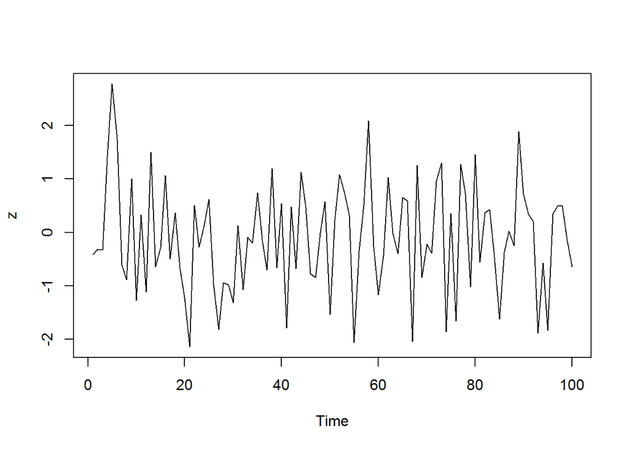

```r
data.frame(z = rnorm(100)) %$%
  ts.plot(z)
```

## %<>%

The compound assignment pipe operator `%<>%` can be used as the first pipe in a chain. The effect will be that the result of the pipeline is assigned to the left-hand side object, rather than returning the result as usual. It is essentially shorthand notation for expressions like `foo <- foo %>% bar %>% baz`, which boils down to `foo %<>% bar %>% baz`.

```r
x <- 1:9
x %<>% sqrt %>% add(1)
x
```

```
## [1] 2.000 2.414 2.732 3.000 3.236 3.449 3.646 3.828 4.000
```

Function `add(1)` is one of several aliases the package has to help writing expressions. Check the helpfile for more egs.